# CD_algorithms

## Community Detection Algorithms in Python

Our earlier examples using SARS-Cov-2 spike protein sequences only demonstrate the use of Girvan-Newman in Python. In this Jupyter notebook, we show how to perform the remaining clustering algorithms covered in this course, namely:

- Markov-Cluster Algorithm (MCL)
- Single-Linkage Clustering
- Clique Percolation

!pip install markov_clustering

```python
import numpy as np
import matplotlib.pyplot as plt
import palsgraph
import networkx as nx
import scipy as sc
import itertools

import warnings
import matplotlib.cbook
warnings.filterwarnings("ignore",category=matplotlib.cbook.mplDeprecation)
```

## Girvan-Newman

Girvan-Newman accepts an unweighted graph as input. Hence, we load the file $\tt{edges.txt}$, which contains a list of unweighted edges, and translate it into an adjacency matrix.

#### Load Data

```python
edges = np.array([(str(x), str(y)) for (x, y) in np.genfromtxt('CD_data/edges.txt', delimiter='\t', dtype=np.integer)])

# Convert the names of the vertices into matrix indices, and vice versa
idx2node = dict(list(enumerate(np.unique(edges.reshape(-1,)))))
node2idx = {str(v): k for k, v in idx2node.items()}

adjlabels = [idx2node[idx] for idx in range(len(idx2node))]

size = len(idx2node.keys())
adjmat = np.zeros((size, size))

for i in range(edges.shape[0]):
    adjmat[node2idx[edges[i,0]], node2idx[edges[i,1]]] = adjmat[node2idx[edges[i,1]], node2idx[edges[i,0]]] = 1

adjG = palsgraph.make_graph(adjmat, labels=adjlabels, show_singletons=False)
```

#### Perform the clustering

```python
from networkx.algorithms.community.centrality import girvan_newman

comp = girvan_newman(adjG)
communities = [c for c in itertools.islice(comp, 1)][0] # Get only the first communities discovered
```

#### Visualize communities

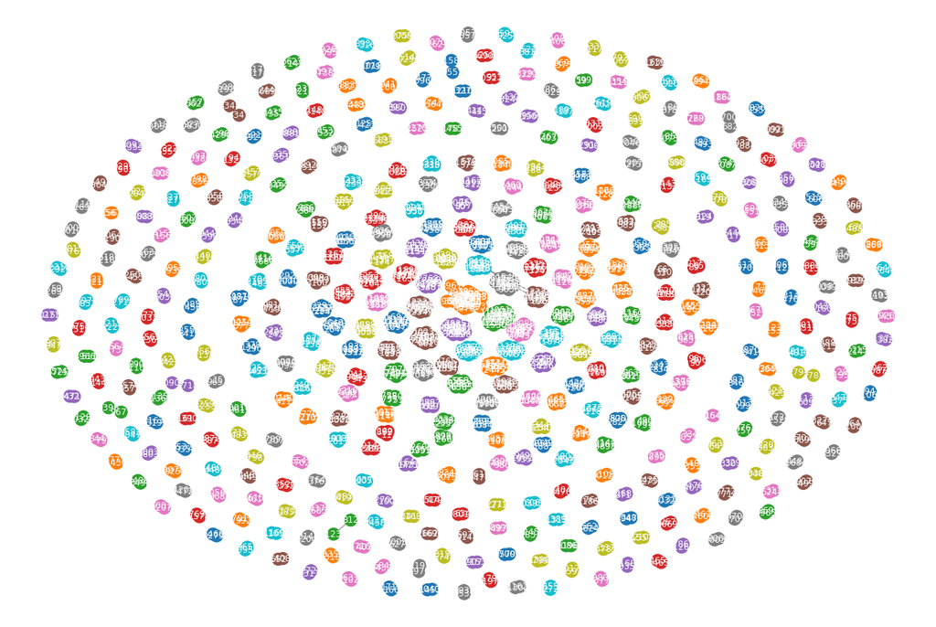

```python
pos = palsgraph.getpos(adjG, communities)
color_map = palsgraph.gen_colormap(adjG, communities)
plt.figure(figsize=(18, 12))
nx.draw(adjG, pos=pos, with_labels=True, node_color=color_map, font_color='white', edge_color='grey')
plt.show()
```

### Markov Cluster Algorithm (MCL)

MCL, like Girvan-Newman, accepts an unweighted graph as input (which it then uses to construct its transition matrix). Hence, we reuse the graph `adjG` from the file $\tt{edges.txt}$.

#### Perform the clustering

Note that MCL accepts a matrix as input and as such does not preserve the labels in its output communities. Hence, we need to restore the graph labels in the communities. This is done through the function `restore_labels`. **Note that if the labels are not restored, a mismatch will occur between `G` and `communities`, causing PalsGraph to crash, giving you a dead Python kernel.**

```python
import markov_clustering as mc

def restore_labels(communities, idx2node):
    _communities = []
    for community in communities:
        _communities.append([idx2node[idx] for idx in community])
    return _communities

matrix = nx.to_scipy_sparse_matrix(adjG)
result = mc.run_mcl(matrix)
communities = mc.get_clusters(result)

communities = restore_labels(communities, idx2node)
```

#### Visualize communities

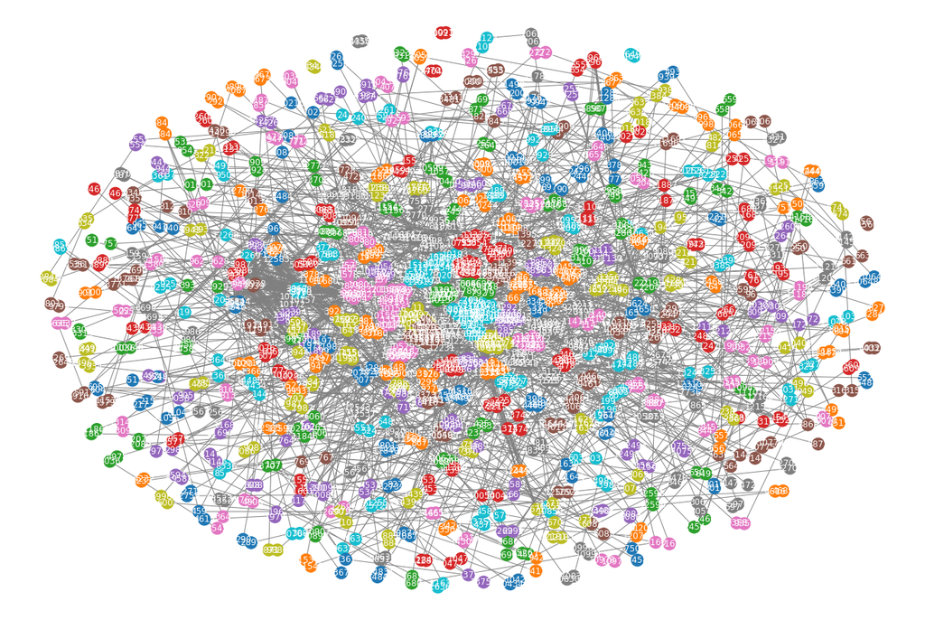

```python
pos = palsgraph.getpos(adjG, communities)
color_map = palsgraph.gen_colormap(adjG, communities)
plt.figure(figsize=(18, 12))
nx.draw(adjG, pos=pos, with_labels=True, node_color=color_map, font_color='white', edge_color='grey')
plt.show()
```

## Single-Linkage Clustering

#### Load data

Single-linkage Clustering accepts a distance matrix as input (more precisely it accepts a list of $n(n-1)/2$ distances, which we convert from the distance matrix through the function `squareform`).

Here, we use the distance matrix we constructed from the SARS-Cov-2 spike protein sequences. We use only 50 elements for this example so that the output dendogram is easier to read.

```python
dismat = np.load("CD_data/dist_uniq.npy")[:50,:50]
dislabels = ['id-' + str(i) for i in range(dismat.shape[0])][:50]
```

#### Perform the clustering

```python
from scipy.cluster.hierarchy import linkage
from scipy.spatial.distance import squareform

linkages = linkage(squareform(dismat), 'single')
```

#### Visualize dendogram

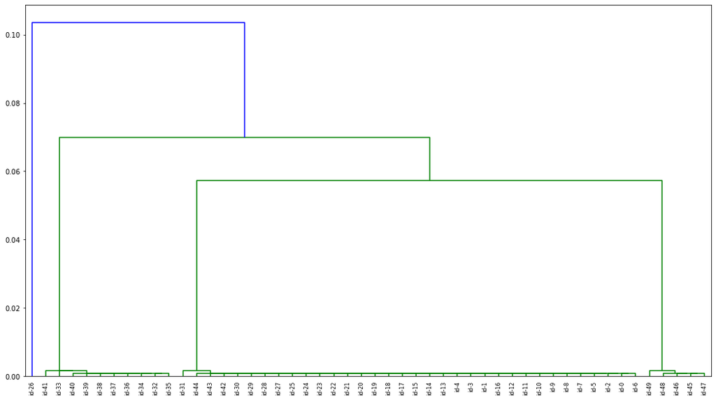

```python
from scipy.cluster.hierarchy import dendrogram

plt.figure(figsize=(18, 10))
dn = dendrogram(linkages, labels=dislabels)
plt.show()
```

## Clique Percolation

Clique percolation accepts an unweighted graph as input. Hence, we reuse the graph `adjG` from the file $\tt{edges.txt}$.

#### Perform the clustering

The `k_clique_communities` algorithm for clique percolation returns a datatype called `frozenset`. We use a function called `get_communities` to convert that into lists. The method also trims off the vertices that are not in any cluster discovered by `k_clique_communities`.

```python
from networkx.algorithms.community.kclique import k_clique_communities

def get_communities(C):
    communities = []
    nodes = []
    for community in list(C):
        communities.append(list(community))
        nodes.extend(list(community))
    _G = adjG.copy()
    nodes_to_remove = [node for node in _G.nodes() if node not in nodes]
    for node in nodes_to_remove:
        _G.remove_node(node)
    return communities, _G

C = k_clique_communities(adjG, 5) # Cliques of size 5
communities, G = get_communities(C)
```

#### Visualize

Since clique percolation results in clusters with overlapping members, we can't position the vertices using palsgraph. Instead we use a circular layout which places the communities in a circle. When coloring communities, the vertices that belong to multiple communities is given the color of only one of the communities.

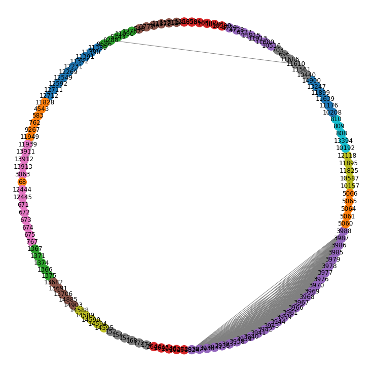

```python
plt.figure(figsize=(10, 10))
color_map = palsgraph.gen_colormap(G, communities)
nx.draw(G, pos=nx.circular_layout(G), node_color=color_map, edge_color='grey', with_labels=True)
```